# Examen final: Aplicacion 1 en R

Rodriguez Nuñez Martin

22/12/2021

## Cargo librerias

```r
# Librerias
library(spdep)
library(gstat)
library(geoR)
```

```r
library(mapview)
library(raster)
library(leaflet)
library(RColorBrewer)
library(PerformanceAnalytics)
library(ggplot2)
library(caret)
library(parallel)
library(nlme)
library(sf)
library(stars)
```

## Cargo base de datos MO_Córdoba

```r
# Carga de base de datos
datos <- read.table("MO_Córdoba.txt", header = T)
head(datos)
```

```
##     MO      NDVI      TWI     Tmed  LS_Factor     PPmed   EPTmed Pendiente
## 1 6.23 0.4594000 10.59900 19.29982 3.18722248  948.0000 371.4556 15.771604
## 2 5.50 0.5653750 10.42025 19.37676 1.20623767 1032.0000 498.6611 11.132813
## 3 5.48 0.5327333 13.07970 21.10466 0.22382224 1128.0000 499.7722  5.687579
## 4 5.25 0.5484500 13.73767 21.81384 0.75282991 1104.0000 430.5056  4.997983
## 5 5.03 0.4077500 17.98333 21.61041 0.03920019 1101.2988 436.7278  1.095690
## 6 4.89 0.4810667 18.40787 23.43194 0.16411683  867.3271 375.0111  2.666414
##      Altura LC_Bosques LC_CultivosAnuales       x       y
## 1 1475.9300     0.0000             0.0000 4310493 6517711
## 2 1206.4839     0.5144             0.0000 4357124 6576685
## 3  741.1904     0.1016             0.0000 4357742 6535684
## 4  794.9297     0.2476             0.0000 4326221 6359046
## 5  556.7622     0.0000             0.9896 4398031 6597115
## 6  580.9411     0.0000             0.0000 4355986 6636919
```

```r
names(datos)
```

```
##  [1] "MO"                 "NDVI"               "TWI"
##  [4] "Tmed"               "LS_Factor"          "PPmed"
##  [7] "EPTmed"             "Pendiente"          "Altura"
## [10] "LC_Bosques"         "LC_CultivosAnuales" "x"
## [13] "y"
```

```r
str(datos)
```

```
## 'data.frame':    340 obs. of  13 variables:
##  $ MO                : num  6.23 5.5 5.48 5.25 5.03 4.89 4.82 4.76 4.68 4.67 ...
##  $ NDVI              : num  0.459 0.565 0.533 0.548 0.408 ...
##  $ TWI               : num  10.6 10.4 13.1 13.7 18 ...
##  $ Tmed              : num  19.3 19.4 21.1 21.8 21.6 ...
##  $ LS_Factor         : num  3.1872 1.2062 0.2238 0.7528 0.0392 ...
##  $ PPmed             : num  948 1032 1128 1104 1101 ...
##  $ EPTmed            : num  371 499 500 431 437 ...
##  $ Pendiente         : num  15.77 11.13 5.69 5 1.1 ...
##  $ Altura            : num  1476 1206 741 795 557 ...
##  $ LC_Bosques        : num  0 0.514 0.102 0.248 0 ...
##  $ LC_CultivosAnuales: num  0 0 0 0 0.99 ...
##  $ x                 : num  4310493 4357124 4357742 4326221 4398031 ...
##  $ y                 : num  6517711 6576685 6535684 6359046 6597115 ...
```

Se puede ver que la base de datos cuenta con 340 observaciones y 13 variables observadas. Entre ellas se encuentran el contenido de materia organica del suelo (MO). Además de posibles covariables como el NDVI (índice de vegetación normalizado promedio), Pendiente del terreno, ETPmed (evapotranspiración median anual), LC_Bosque (% de superficie del entorno con cobertura de bosque). Cada uno de los 340 puntos cuenta con información de las coordenadas (x e y).

## Cargo la base de datos grilla3000m_Cba

```r
# Carga de base de datos
grilla <- read.table("grilla3000m_Cba.txt", header = T)
head(grilla)
```

```
##         x       y      NDVI   EPTmed Pendiente LC_Bosques
## 1 4237901 6568953 0.4548459 272.8060 0.3435229          0
## 2 4237387 6566095 0.4449871 271.2456 0.3751776          0
## 3 4236944 6563228 0.4507083 276.3173 0.3363041          0
## 4 4236934 6560238 0.4450344 278.7616 0.3110625          0
## 5 4236941 6557238 0.4409610 281.4887 0.3859387          0
## 6 4236948 6554238 0.4270873 271.7890 0.3317374          0
```

```r
names(grilla)
```

```
## [1] "x"          "y"          "NDVI"       "EPTmed"     "Pendiente"
## [6] "LC_Bosques"
```

```r
str(grilla)
```

```
## 'data.frame':    18436 obs. of  6 variables:
##  $ x         : num  4237901 4237387 4236944 4236934 4236941 ...
##  $ y         : num  6568953 6566095 6563228 6560238 6557238 ...
##  $ NDVI      : num  0.455 0.445 0.451 0.445 0.441 ...
##  $ EPTmed    : num  273 271 276 279 281 ...
##  $ Pendiente : num  0.344 0.375 0.336 0.311 0.386 ...
##  $ LC_Bosques: num  0 0 0 0 0 0 0 0 0 0 ...
```

Por otra parte la base de datos grilla3000m_Cba presenta la información de 18436 observaciones para un total de 6 variables. Esta base hace referencia a un conjunto de puntos dispuestos en forma regular y separados a una distancia de 3 km, para toda la provincia de Cordoba. En cada punto se tiene información de las coordenadas (x e y) ademas de los valores de algunas covariables (NDVI, Pendiente, ETPmed, LC_Bosque).

Esta segunda base de datos no cuenta con la principal variable de interes en el analisis que es el contenido de materia organica del suelo, por lo que a partir de las variables predictoras observadas en los sitios de la base de datos grilla se buscara predecir la variable de interes (MO).

## Consignas

A partir de los datos provistos (muestra) el objetivo del presente es predecir el contenido de MO en sitios no observados del dominio de interés (provincia de Córdoba). Se solicita realizar un análisis geoestadístico con soporte computacional y presentar los principales resultados del análisis en base a los siguientes puntos:

## 1) Realice un análisis descriptivo de los datos (medidas resumen, distribución de la variable, evaluación de tendencia).

### Graficos Exploratorios

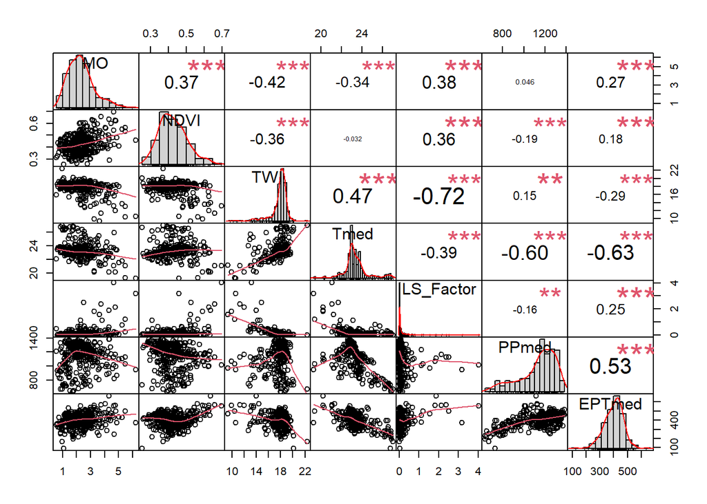

```r
chart.Correlation(datos[, 1:7], histogram = TRUE, pch = 19)
```

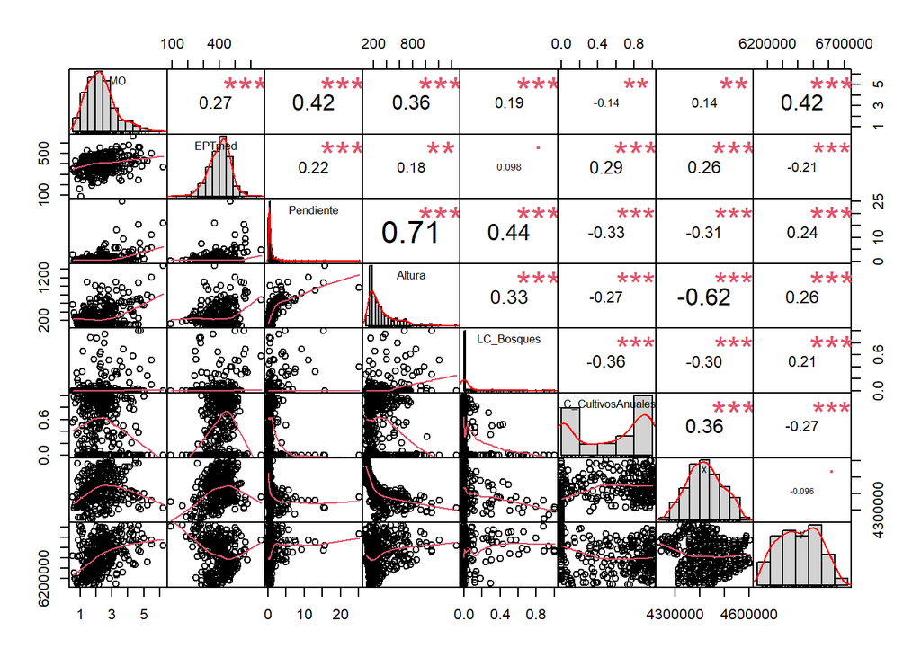

```r
chart.Correlation(datos[, c(1,seq(7,13,1))], histogram = TRUE, pch = 19)
```

Se puede ver que el contenido de materia organica es una variable respuesta con una leve asimetria positiva y que no se encuentra fuertemente correlacionada con ninguna de las variables, a pesar que tiene una correlacion moderada con algunas de ellas.

Por otra parte, se pueden observar fuertes correlaciones entre las distintas variables observadas, como lo es el caso de TW y LS_Factor, PPmed y EPTmed, PPmed y Tmed, altura y pendiente, x y altura.

A partir del grafico de puntos se puede ver algunas variables predictores que parecen tener una tendencia lineal positiva con el contenido de materia organica, estas son:

- NDVI con un coeficiente de correlacion de 0.37.
- LS_factor con un coeficiente de correlacion de 0.38.
- Pendiente con un coeficiente de correlacion de 0.42.
- Altura con un coeficiente de correlacion de 0.36.
- La coordenada y con un coeficiente de correlacion de 0.42.

Por otra parte se nota una tendencia lineal negativa con el contenido de materia organica por parte de las variables: * TW con un coeficiente de correlacion de -0.42. * Tmed con un coeficiente de correlacion de -0.34.

La mayoria de las correlaciones observadas son signifcativas y esto podria estar indicando que existe una verdadera tendencia que deberiamos quitar a los datos antes de trabajar con ellos, por lo que lo mas adecuado para trabajar con esta base podria ser un krigging con deriva externa o con un kirgging combinado con algun metodo de regresion.

### Analisis Grafico:

```r
datos <- st_as_sf(datos, coords = c("x", "y"), crs = 22174)
datos
```

```
## Simple feature collection with 340 features and 11 fields
## Geometry type: POINT
## Dimension:     XY
## Bounding box:  xmin: 4235783 ymin: 6133606 xmax: 4603205 ymax: 6722853
## Projected CRS: POSGAR 98 / Argentina 4
## First 10 features:
##      MO      NDVI      TWI     Tmed  LS_Factor     PPmed   EPTmed Pendiente
## 1  6.23 0.4594000 10.59900 19.29982 3.18722248  948.0000 371.4556 15.771604
## 2  5.50 0.5653750 10.42025 19.37676 1.20623767 1032.0000 498.6611 11.132813
## 3  5.48 0.5327333 13.07970 21.10466 0.22382224 1128.0000 499.7722  5.687579
## 4  5.25 0.5484500 13.73767 21.81384 0.75282991 1104.0000 430.5056  4.997983
## 5  5.03 0.4077500 17.98333 21.61041 0.03920019 1101.2988 436.7278  1.095690
## 6  4.89 0.4810667 18.40787 23.43194 0.16411683  867.3271 375.0111  2.666414
## 7  4.82 0.6215833 16.65102 23.50978 0.15126176  996.0000 500.3944  4.731873
## 8  4.76 0.6256500 12.00967 20.21766 2.14154387 1164.9677 563.8722  7.565994
## 9  4.68 0.4207750 15.63999 25.92830 0.21234286  822.7968 244.8556  1.939424
## 10 4.67 0.6959000 13.19944 21.07895 4.03814697 1016.4343 558.3444 15.319247
##       Altura LC_Bosques LC_CultivosAnuales                geometry
## 1  1475.9300     0.0000             0.0000 POINT (4310493 6517711)
## 2  1206.4839     0.5144             0.0000 POINT (4357124 6576685)
## 3   741.1904     0.1016             0.0000 POINT (4357742 6535684)
## 4   794.9297     0.2476             0.0000 POINT (4326221 6359046)
## 5   556.7622     0.0000             0.9896 POINT (4398031 6597115)
## 6   580.9411     0.0000             0.0000 POINT (4355986 6636919)
## 7   671.7534     0.9976             0.0000 POINT (4304169 6460434)
## 8   723.6516     0.3620             0.0000 POINT (4377903 6556982)
## 9   261.5529     0.0000             0.0000 POINT (4375787 6714974)
## 10 1089.4109     1.0000             0.0000 POINT (4316079 6475163)
```

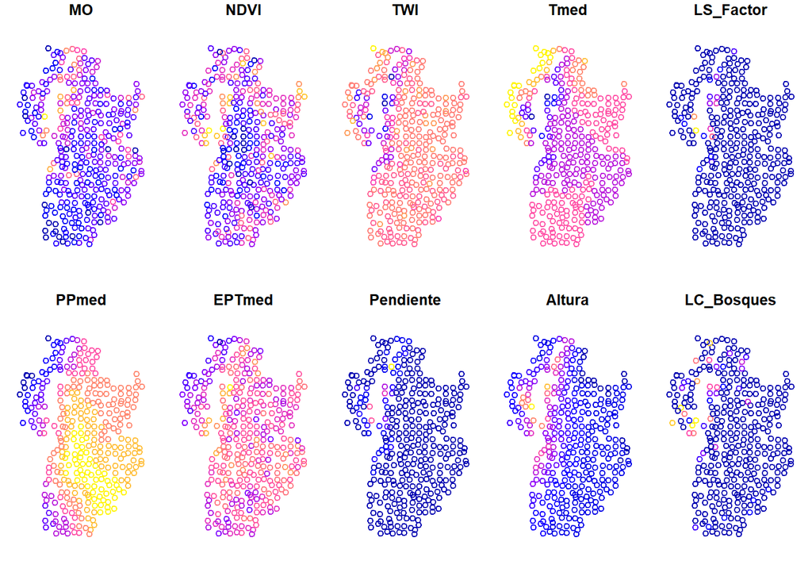

```r
# Visualizacion
plot(datos)
```

A partir de este grafico se puede analizar la variabilidad de cada una de las variables que se encuentran en la base de datos. Se aprecia que las que varian mayormente son la temperatura media y presipitacion media. Luego en menor medida las variables TWI y la evapotranspiracion media, seguidas por el contenido de materia organica y el NDVI. Las restantes variables se mantienen relativamente constantes a lo largo del territorio provincial.

#### Concentro analisis en el contenido de materia organica:

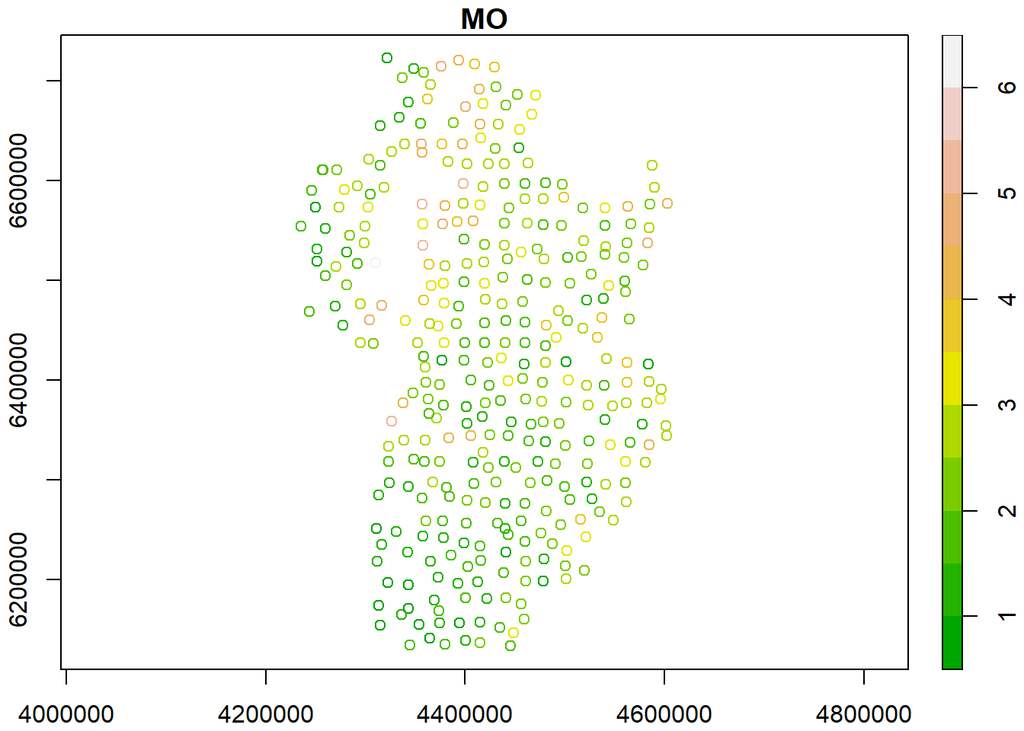

```r
plot(
  datos["MO"],
  key.pos = 4,
  axes = TRUE,
  key.width = lcm(1.5),
  key.length = 1,
  pal = terrain.colors
)
```

## 2) Realice el ajuste de semivariogramas empíricos y teóricos considerando diferentes modelos de correlación espacial suponiendo un proceso estacionario. Seleccione el modelo de acuerdo con criterios de bondad de ajuste.

### Ajuste semivariograma empirico suponiendo un proceso estacionario:

```r
semi_exp <- variogram(MO ~ 1, datos)
```

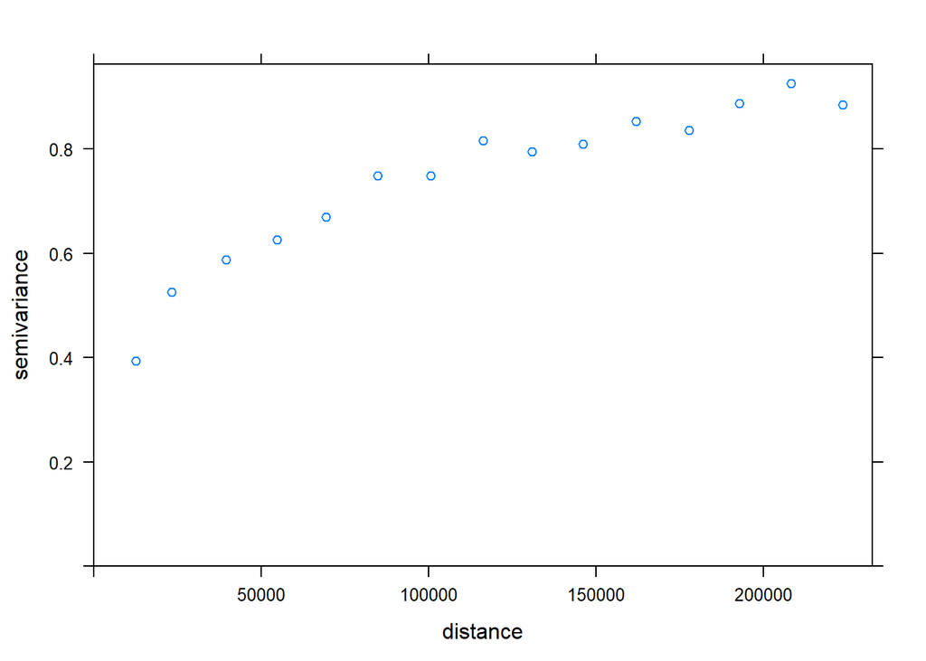

```r
plot(semi_exp)
```

```r
semi_exp
```

```
##      np      dist     gamma dir.hor dir.ver   id
## 1    70  12666.03 0.3933621       0       0 var1
## 2   865  23310.49 0.5252897       0       0 var1
## 3  1249  39519.46 0.5874068       0       0 var1
## 4  1528  54674.70 0.6262559       0       0 var1
## 5  1899  69263.73 0.6689488       0       0 var1
## 6  2255  84757.22 0.7482082       0       0 var1
## 7  2518 100630.85 0.7486364       0       0 var1
## 8  2579 116165.05 0.8159850       0       0 var1
## 9  2711 130939.76 0.7949422       0       0 var1
## 10 2921 146171.45 0.8095709       0       0 var1
## 11 3064 161926.73 0.8527374       0       0 var1
## 12 2939 177677.81 0.8365383       0       0 var1
## 13 2904 192870.58 0.8870118       0       0 var1
## 14 2808 208096.82 0.9258529       0       0 var1
## 15 2738 223558.65 0.8852971       0       0 var1
```

En el semivariograma experimental ajustado, puede verse que a partir de los 150000 metros este tiende a estabilizarse. Al ser la cantidad de puntos con los cuales se calcula cada uno de estos coeficientes mayor a 30 sus resultados son confiables. Ademas se aprecian 15 semivarianzas estimadas.

El calculo del primer coeficiente de semivarianza, es muy importante debido a que define el nugget, y es el que con menor cantidad de puntos se encuentra calculado, por este motivo procedere a modificar el parametro de width para mejorar esta estimacion. Ademas de ello tambien analizare como varia la semivarianza al aumentar la distancia para el calculo de los coeficientes con el parametro cutoff.

```r
semi_exp <- variogram(MO ~ 1, datos,width=18000,cutoff=2000000)
```

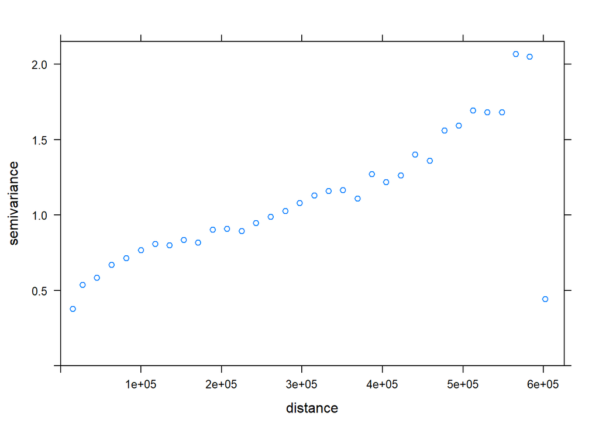

```r
plot(semi_exp)
```

```r
semi_exp
```

```
##      np      dist     gamma dir.hor dir.ver   id
## 1   185  15249.25 0.3794754       0       0 var1
## 2  1057  26945.98 0.5359960       0       0 var1
## 3  1604  45013.03 0.5855354       0       0 var1
## 4  2138  63234.78 0.6701893       0       0 var1
## 5  2551  81411.74 0.7144084       0       0 var1
## 6  2847  99544.63 0.7662612       0       0 var1
## 7  3031 117424.86 0.8079732       0       0 var1
## 8  3357 135232.21 0.7985394       0       0 var1
## 9  3382 153220.26 0.8367471       0       0 var1
## 10 3399 170886.16 0.8181883       0       0 var1
## 11 3416 188703.51 0.9039404       0       0 var1
## 12 3340 206688.41 0.9100518       0       0 var1
## 13 3173 224800.98 0.8943029       0       0 var1
## 14 2972 242805.74 0.9483970       0       0 var1
```

[output cut: 20 more lines]

El semivariograma experimental obtenido se encuentra calculado con una mayor cantidad de puntos por coeficiente, es decir que sus valores son mas confiables. Ademas al analizar una distancia mayor a la previamente graficada, se puede ver que el semivariograma sigue una tendencia que parece nunca estabilizarse aumentando continuamente. Esto habla de una clara tendencia existente en la varible que estamos ajustando. A partir del analisis conlcluyo que se trata de un prceso no estacionario, con una clara tendencia que esperamos poder corregir con la inclucion de algunas covariables en el modelo.

### Ajuste semivariograma teorico suponiendo un proceso estacionario:

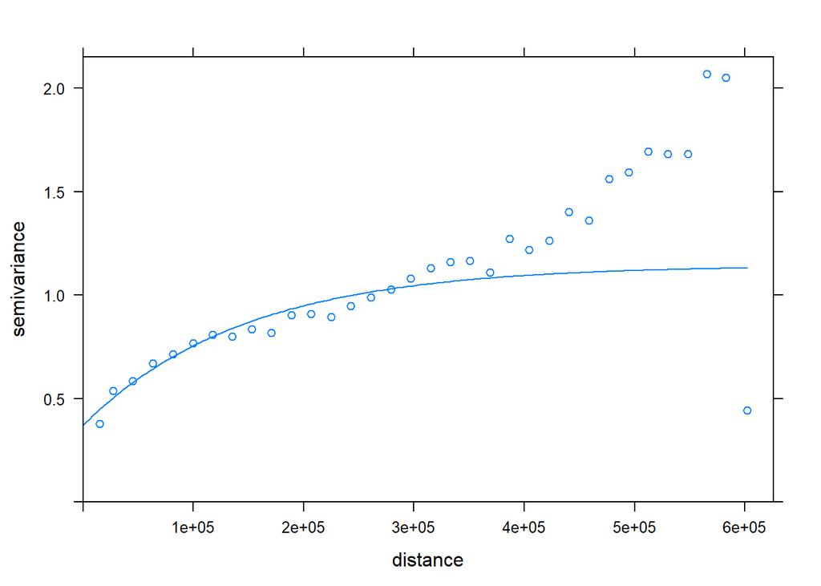

```r
# Ajuste automatico de modelos
v.fit_todos <- fit.variogram(semi_exp, vgm(c("Exp", "Sph", "Gau")))
plot(semi_exp, v.fit_todos)
```

```r
attr(v.fit_todos, 'SSErr')
```

```
## [1] 1.143961e-08
```

```r
v.fit_todos
```

```
##   model     psill    range
## 1   Nug 0.3714324      0.0
## 2   Exp 0.7721250 145218.2
```

Se puede apreciar que el mejor modelo teorico que ajusta a los datos es el exponencial con un nugget de 0.3714324 y un rango de 145218.2. Pero volveremos a modelar todo con tendencia como consecuencia de lo observado previamente.

## 3) Realice el ajuste de semivariogramas empíricos y teóricos incluyendo tendencias para las covariables relevadas y/o coordenadas.

### Ajuste semivariograma empirico con tendencia:

Para corregir el problema de la inestabilizacion del semivariograma, voy a proceder a incluir tendencia para las covariables relevadas. Para comenzar incluire solo las variables que se encuentran relevadas en los puntos donde el objetivo es predecir la variable contenido de materia organica ya que es desconocido. De este modo si logro la estabilizacion con estas variables me favoreceria mucho para poder obtener predicciones con un modelo adecuado en estos sitios. Las variables recopiladas en los sitios donde el contenido de materia organica es desconocido son: * La coordenada x. * La coordenada y. * El NDVI.  
* La evapotranspiracion media.  
* La Pendiente.  
* El LC_Bosques.

Para determinar cuales variables seran las que incluire en el modelo, procedere a ajustar una regresion multiple con un procedimiento de seleccion de variables del tipo stepwise.

```r
datos2 <- read.table("MO_Córdoba.txt", header = T)
lm.full <- lm(MO ~ x + y + NDVI + EPTmed + Pendiente + LC_Bosques, data = datos2)
lm.null <- lm(MO ~ 1, data = datos2)
coordinates(datos2) = ~x+y
```

```r
model.aic.both <- step(lm.null, direction = "both", trace = 1, scope = ~ x + y + NDVI + EPTmed + Pendiente + LC_Bosques)
```

```
## Start:  AIC=-18.91
## MO ~ 1
##
##              Df Sum of Sq    RSS     AIC
## + y           1    56.194 263.53 -82.627
## + Pendiente   1    55.978 263.74 -82.349
## + NDVI        1    43.097 276.63 -66.136
## + EPTmed      1    23.191 296.53 -42.510
## + LC_Bosques  1    12.097 307.63 -30.022
## + x           1     6.290 313.43 -23.664
## <none>                    319.72 -18.908
##
## Step:  AIC=-82.63
## MO ~ y
##
##              Df Sum of Sq    RSS      AIC
## + EPTmed      1    42.671 220.86 -140.687
## + Pendiente   1    34.263 229.27 -127.983
## + NDVI        1    26.689 236.84 -116.932
## + x           1    10.512 253.02  -94.468
## + LC_Bosques  1     3.902 259.63  -85.700
## <none>                    263.53  -82.627
## - y           1    56.194 319.72  -18.908
##
## Step:  AIC=-140.69
## MO ~ y + EPTmed
##
##              Df Sum of Sq    RSS      AIC
## + Pendiente   1    17.595 203.26 -166.914
## + NDVI        1    14.128 206.73 -161.163
## + x           1     2.826 218.03 -143.066
## <none>                    220.86 -140.687
## + LC_Bosques  1     1.041 219.82 -140.293
## - EPTmed      1    42.671 263.53  -82.627
## - y           1    75.674 296.53  -42.510
##
## Step:  AIC=-166.91
## MO ~ y + EPTmed + Pendiente
##
##              Df Sum of Sq    RSS      AIC
```

[output cut: 16 more lines]

```
## - x           1    12.975 203.26 -166.91
## - Pendiente   1    27.743 218.03 -143.07
## - y           1    45.371 235.66 -116.63
##
## Step:  AIC=-193.26
## MO ~ y + EPTmed + Pendiente + x + NDVI
##
##              Df Sum of Sq    RSS     AIC
## <none>                    185.91 -193.26
## + LC_Bosques  1     0.732 185.17 -192.60
## - NDVI        1     4.381 190.29 -187.34
## - x           1     9.834 195.74 -177.73
## - EPTmed      1    10.801 196.71 -176.06
## - Pendiente   1    18.759 204.66 -162.57
## - y           1    40.042 225.95 -128.94
```

```r
summary(model.aic.both)
```

```
##
## Call:
## lm(formula = MO ~ y + EPTmed + Pendiente + x + NDVI, data = datos2)
##
## Residuals:
##      Min       1Q   Median       3Q      Max
## -2.44721 -0.46690 -0.06184  0.37946  2.51941
##
## Coefficients:
##               Estimate Std. Error t value Pr(>|t|)
## (Intercept) -2.519e+01  2.889e+00  -8.721  < 2e-16 ***
## y            2.420e-06  2.853e-07   8.482 7.28e-16 ***
## EPTmed       2.693e-03  6.113e-04   4.405 1.43e-05 ***
## Pendiente    1.246e-01  2.147e-02   5.805 1.49e-08 ***
## x            2.282e-06  5.429e-07   4.203 3.38e-05 ***
## NDVI         1.600e+00  5.703e-01   2.806  0.00532 **
## ---
## Signif. codes:  0 '***' 0.001 '**' 0.01 '*' 0.05 '.' 0.1 ' ' 1
##
## Residual standard error: 0.7461 on 334 degrees of freedom
## Multiple R-squared:  0.4185, Adjusted R-squared:  0.4098
## F-statistic: 48.08 on 5 and 334 DF,  p-value: < 2.2e-16
```

La unica variable que no quedo seleccionada por este metodo para ser incluida en el modelo es la variable LC_Bosques por lo que no sera incluida en el ajuste con tendencia.

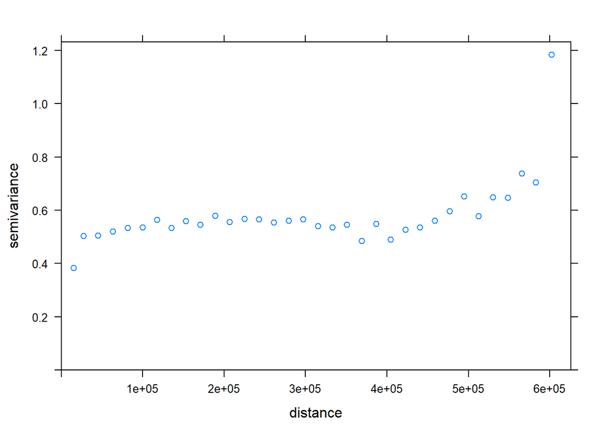

```r
semi_exp_trend <-
  variogram(MO ~ x+y+NDVI + EPTmed + Pendiente, data = datos2, width=18000,cutoff=2000000)
plot(semi_exp_trend)
```

```r
semi_exp_trend
```

```
##      np      dist     gamma dir.hor dir.ver   id
## 1   185  15249.25 0.3831091       0       0 var1
## 2  1057  26945.98 0.5042644       0       0 var1
## 3  1604  45013.03 0.5058432       0       0 var1
## 4  2138  63234.78 0.5206646       0       0 var1
## 5  2551  81411.74 0.5349172       0       0 var1
## 6  2847  99544.63 0.5365001       0       0 var1
## 7  3031 117424.86 0.5641849       0       0 var1
## 8  3357 135232.21 0.5338852       0       0 var1
## 9  3382 153220.26 0.5597488       0       0 var1
## 10 3399 170886.16 0.5462982       0       0 var1
## 11 3416 188703.51 0.5791501       0       0 var1
## 12 3340 206688.41 0.5570149       0       0 var1
## 13 3173 224800.98 0.5681457       0       0 var1
## 14 2972 242805.74 0.5671592       0       0 var1
```

[output cut: 20 more lines]

Al ajustar el semivariograma experimental con tendencia vemos que tiende a estabilizarse, a pesar de tener algunos valores que a grandes distancias comienzan a aumentar su semivarianza. Por lo tanto el modelo es aceptable, a partir del analisis grafico se puede ver que el rango es de 100000 y el efecto nugget de 0.38. Puede afirmarse que al ser la cantidad de puntos con las cuales se calcula cada uno de estos coeficientes es mayor a 30 sus resultados son confiables.

### Ajuste semivariograma teorico suponiendo un proceso estacionario:

```r
v.fit_todos_trend <-
  fit.variogram(semi_exp_trend, vgm(nugget=0.39, range=100000,model=c("Exp", "Sph", "Gau")))
```

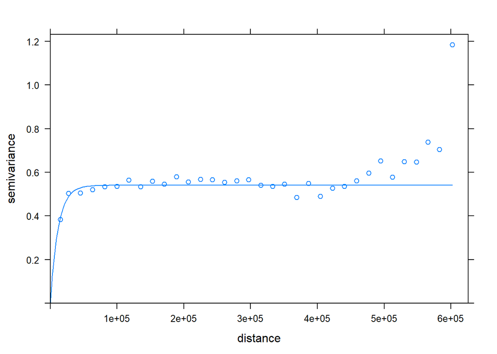

```r
plot(semi_exp_trend, v.fit_todos_trend)
```

```r
attr(v.fit_todos_trend, 'SSErr')
```

```
## [1] 1.728778e-09
```

```r
v.fit_todos_trend
```

```
##   model     psill    range
## 1   Exp 0.5405333 11556.32
```

El mejor modelo teorico que ajusta al semivariograma definiendo el nugget y el rango parece ser el exponencial con una suma de residuos cuadrados minima de 1.728778e-09.

## 4) Obtenga la predicción espacial utilizando sólo la información de la variable respuesta (kriging ordinario) e incluyendo las covariables en el análisis (kriging regresión o random forest kriging).

### Kriging Ordinario

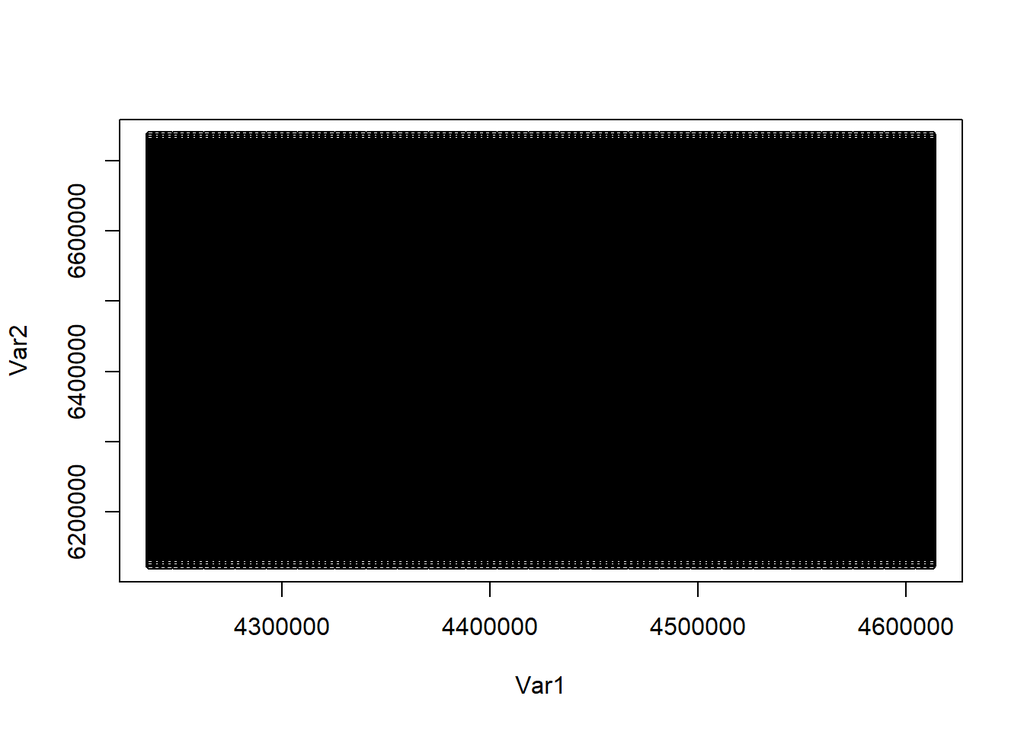

```r
library(gstat)
# Generacion de grilla de prediccion
gr <- pred_grid(grilla, by = 3000)
plot(gr)
```

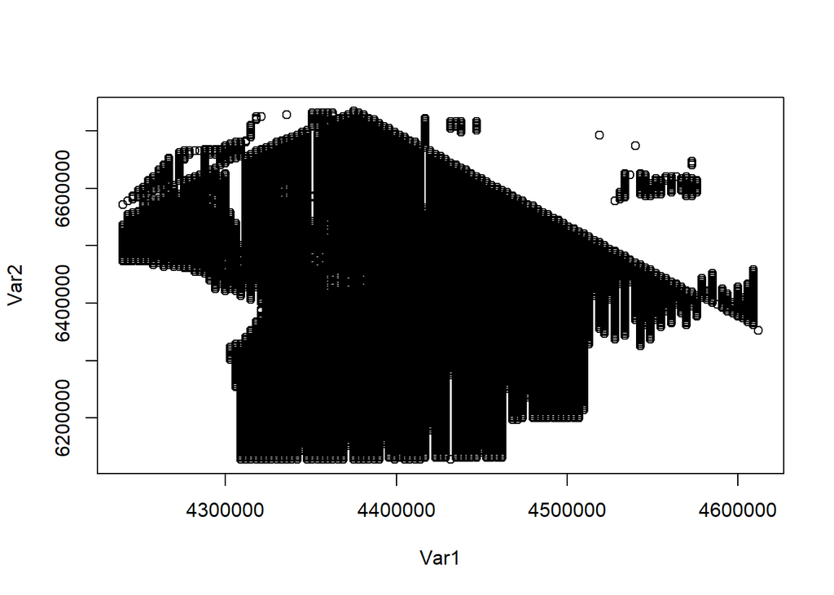

```r
gri <- polygrid(gr, bor = grilla)
plot(gri)
```

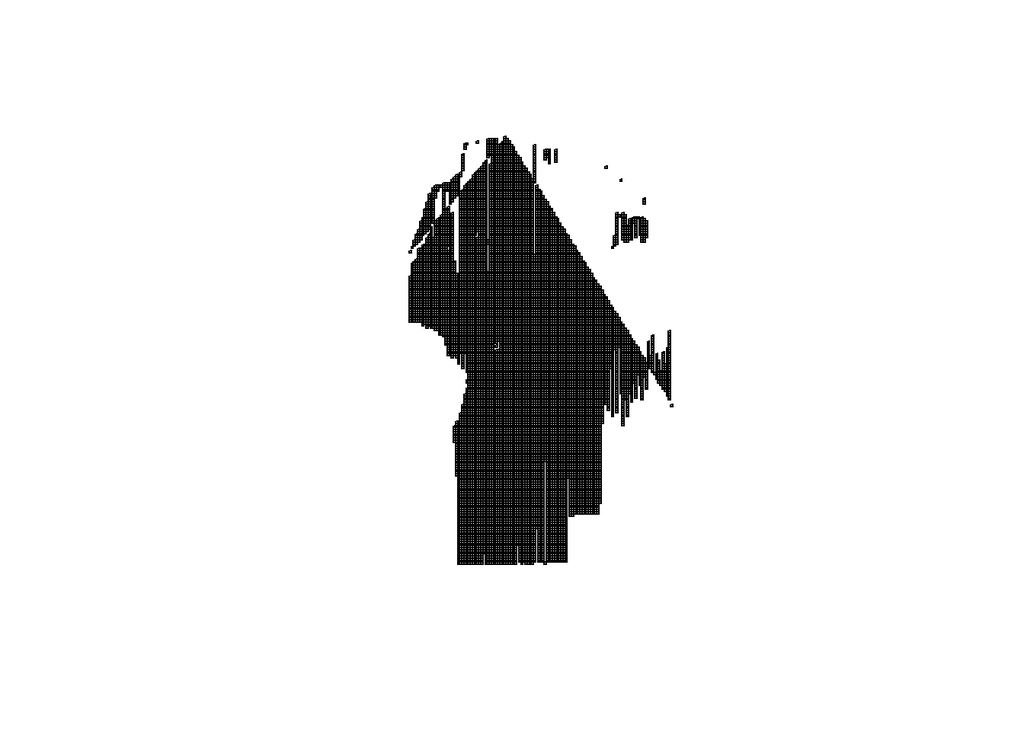

```r
names(gri)[1] <- paste("x")
names(gri)[2] <- paste("y")
gridded(gri) = ~ x + y
plot(gri)
```

```r
gri <- st_as_sf(gri)
st_crs(gri) <- 22174
gri
```

```
## Simple feature collection with 13421 features and 0 fields
## Geometry type: POINT
## Dimension:     XY
## Bounding box:  xmin: 4238434 ymin: 6126517 xmax: 4613434 ymax: 6735517
## Projected CRS: POSGAR 98 / Argentina 4
## First 10 features:
##                   geometry
## 1  POINT (4308934 6128017)
## 2  POINT (4311934 6128017)
## 3  POINT (4314934 6128017)
## 4  POINT (4317934 6128017)
## 5  POINT (4320934 6128017)
## 6  POINT (4323934 6128017)
## 7  POINT (4326934 6128017)
## 8  POINT (4329934 6128017)
## 9  POINT (4332934 6128017)
## 10 POINT (4335934 6128017)
```

```r
# mapview(gri)

# Cargo nuevamente los datos
datos <- read.table("MO_Córdoba.txt", header = T)
datos <- st_as_sf(datos, coords = c("x", "y"), crs = 22174)
# coordinates(datos) = ~x+y

# Kriging Ordinario
v.fit_todos
```

```
##   model     psill    range
## 1   Nug 0.3714324      0.0
## 2   Exp 0.7721250 145218.2
```

```r
f.1 <- as.formula(MO ~ 1)
kriging_grilla <- gstat::krige(f.1, datos, gri, v.fit_todos)
```

```
## [using ordinary kriging]
```

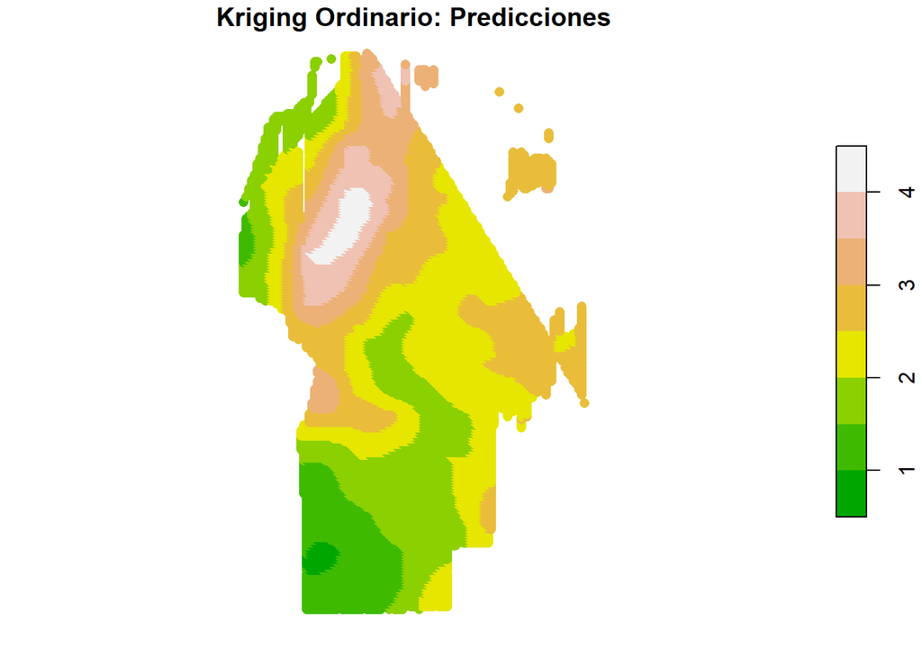

```r
plot(kriging_grilla["var1.pred"],
     main = "Kriging Ordinario: Predicciones",
     pal = terrain.colors,
     pch = 16)
```

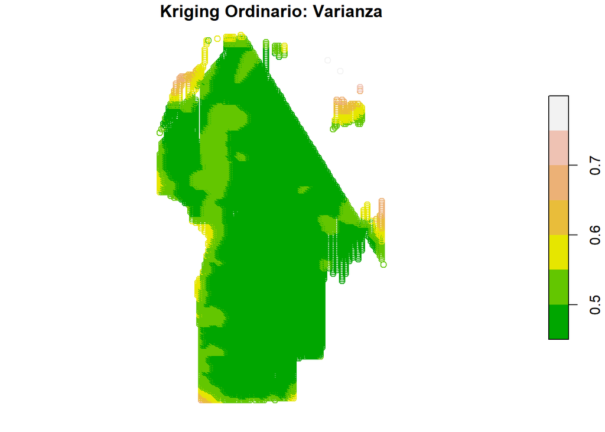

```r
plot(kriging_grilla["var1.var"], main = "Kriging Ordinario: Varianza", pal =
       terrain.colors)
```

```r
kriging_grilla$DE_pred <- sqrt(kriging_grilla$var1.var)
head(kriging_grilla)
```

```
## Simple feature collection with 6 features and 3 fields
## Geometry type: POINT
## Dimension:     XY
## Bounding box:  xmin: 4308934 ymin: 6128017 xmax: 4323934 ymax: 6128017
## Projected CRS: POSGAR 98 / Argentina 4
##   var1.pred  var1.var                geometry   DE_pred
## 1  1.259788 0.6623720 POINT (4308934 6128017) 0.8138624
## 2  1.257825 0.6515924 POINT (4311934 6128017) 0.8072128
## 3  1.257391 0.6412403 POINT (4314934 6128017) 0.8007748
## 4  1.258499 0.6312366 POINT (4317934 6128017) 0.7945040
## 5  1.261110 0.6214535 POINT (4320934 6128017) 0.7883233
## 6  1.265134 0.6117314 POINT (4323934 6128017) 0.7821326
```

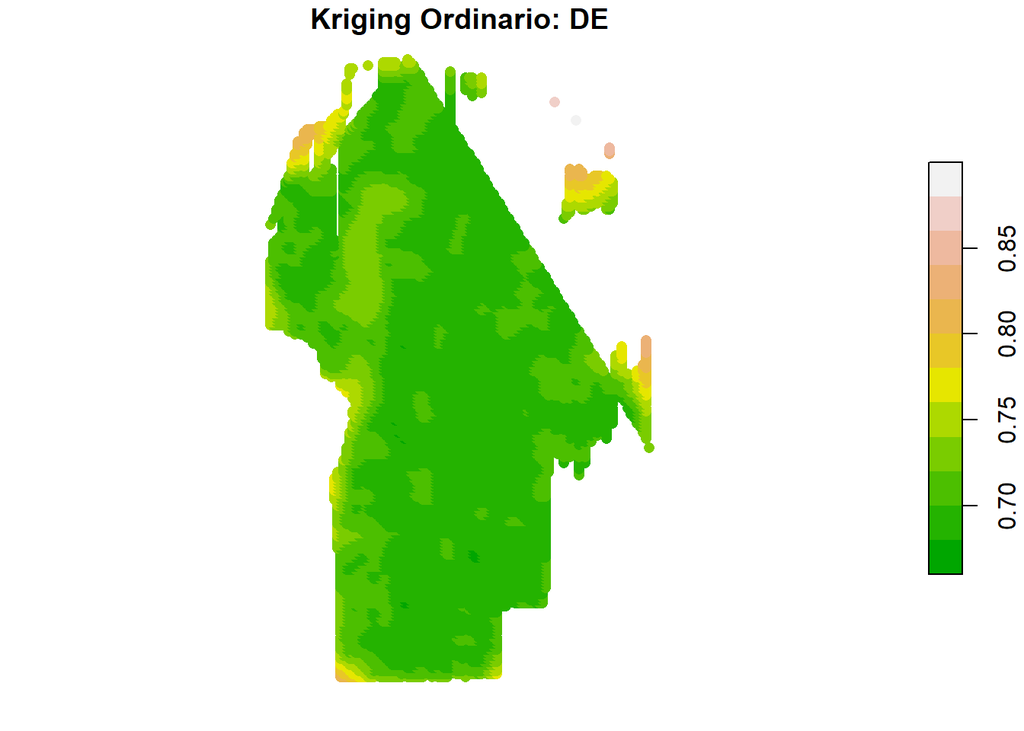

```r
plot(kriging_grilla["DE_pred"],
     main = "Kriging Ordinario: DE",
     pal = terrain.colors,
     pch = 16)
```

En esta parte del codigo se puede observar todo el procedimiento necesario para poder realizar las predicciones del contenido de materia organica en los puntos que esta variable es desconocida. Lo primero que debe hacerse es crear una grilla de puntos regular con las distancias a las cuales se encuentran separados los puntos en los cuales se quiere predecir, en este caso 3000 metros.

Luego esa grilla regular es recortada con el objetivo de solo incluir los puntos que realmente son de interes o que tenemos definidos. Ademas se define el sistema de coordendas de referencia para la provincia de Cordoba en Argentina. Finalmente generamos una visualizacion para cersiorarnos de que los puntos hayan sido cargados adecuadamente.

Luego se procede a la interpolacion de los valores desconocidos por medio de kriging ordinario suponiendo un modelo estacionario donde la variable respuesta no incluye ninguna variable regresora.

A partir de las predicciones obtenidas, podemos observar que el contenido de materia organica en el modelo de independencia parece estar fuertemente correlacionado con la altura como consecuencia de que los mayores contenidos se dan a medida que nos aproximamos a las Sierras de Cordoba (aumenta la altura) y a medida que nos alejamos de ella estos comienzan a disminuir. La varianza de las predicciones parece ser baja en la mayor parte del terreno de la provincia.

### Kriging Ranfom Forest

Decidi optar por el kriging Random Forest, ya que a pesar de ser pocas las covariables concideradas en el modelo con tendencia, estas describen correlaciones que prefiero controlar. El algoritmo de Random Forest genera una seleccion aleatoria de las variables predictoras al construir cada uno de los arboles del desierto, de esta forma al tomar solo “mtry” variables en la construccion de cada uno de ellos combate la correlacion existente entre los predictores.

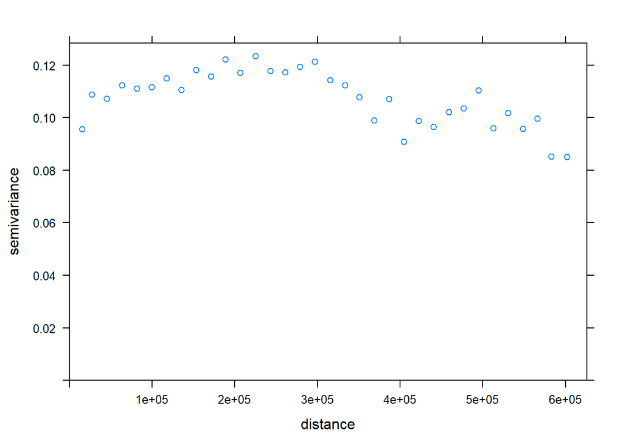

```r
# Ajuste del RF con libreria caret
seed <- 7

# Grilla de hiperparametro del mtry
mtry <- expand.grid(mtry = seq(2, 5, 1))

# 10 fold cross validation
fitControl <-
  trainControl(method = "cv",
               number = 10,
               allowParallel = T)


datos2 <- read.table("MO_Córdoba.txt", header = T)

# Ajuste del modelo de RF
set.seed(seed)
train_rf <-
  train(
    MO ~ x+y+NDVI + EPTmed + Pendiente,
    data = datos2,
    method = "rf",
    importance = T,
    tuneGrid = mtry,
    trControl = fitControl
  )

# Incorporamos los residuos del MLR a la base de datos
datos2$residuosRF <- datos2$MO - predict(train_rf, newdata = datos2)

coordinates(datos2) = ~x+y

# Ajuste de semivariograma experimetal y teorico a los residuos del RF
# datos2 <- st_as_sf(datos2, coords = c("x", "y"), crs = 22174)

semi_exp_trend <-
  variogram(residuosRF ~ x + y + NDVI + EPTmed + Pendiente, data = datos2, width=18000,cutoff=2000000)
plot(semi_exp_trend)
```

```r
semi_exp_trend
```

```
##      np      dist      gamma dir.hor dir.ver   id
## 1   185  15249.25 0.09557129       0       0 var1
## 2  1057  26945.98 0.10890023       0       0 var1
## 3  1604  45013.03 0.10722489       0       0 var1
## 4  2138  63234.78 0.11235750       0       0 var1
## 5  2551  81411.74 0.11112374       0       0 var1
## 6  2847  99544.63 0.11160344       0       0 var1
## 7  3031 117424.86 0.11501436       0       0 var1
## 8  3357 135232.21 0.11067335       0       0 var1
## 9  3382 153220.26 0.11825093       0       0 var1
## 10 3399 170886.16 0.11564211       0       0 var1
## 11 3416 188703.51 0.12226486       0       0 var1
## 12 3340 206688.41 0.11715232       0       0 var1
## 13 3173 224800.98 0.12348180       0       0 var1
## 14 2972 242805.74 0.11777588       0       0 var1
```

[output cut: 20 more lines]

```r
v.fit_todos_trend <-
  fit.variogram(semi_exp_trend, vgm(nugget = 0.095, range = 160000, model=c("Exp", "Sph", "Gau", "Mat")))
```

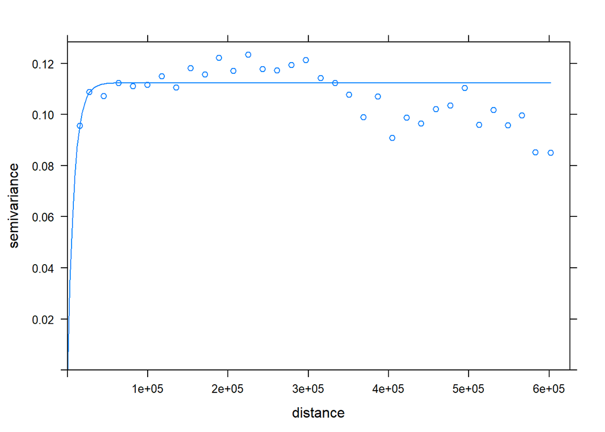

```r
plot(semi_exp_trend, v.fit_todos_trend)
```

```r
attr(v.fit_todos_trend, 'SSErr')
```

```
## [1] 6.116976e-11
```

```r
v.fit_todos_trend
```

```
##   model     psill    range kappa
## 1   Mat 0.1123919 8032.806   0.5
```

```r
# Vuelvo a cargar la grilla
gr <- pred_grid(grilla, by = 3000)
gri <- polygrid(gr, bor = grilla)
names(gri)[1] <- paste("x")
names(gri)[2] <- paste("y")
gridded(gri) = ~ x + y
gri <- st_as_sf(gri)
st_crs(gri) <- 22174

# Vuelvo a cargar los datos
datos2 <- read.table("MO_Córdoba.txt", header = T)
datos2$residuosRF <- datos2$MO - predict(train_rf, newdata = datos2)
datos2 <- st_as_sf(datos2, coords = c("x", "y"), crs = 22174)

# Kriging sobre residuos del RF
f.1 <- as.formula(residuosRF ~ 1)
kgresRF <- krige(f.1 , datos2, gri, model = v.fit_todos_trend)
```

```
## [using ordinary kriging]
```

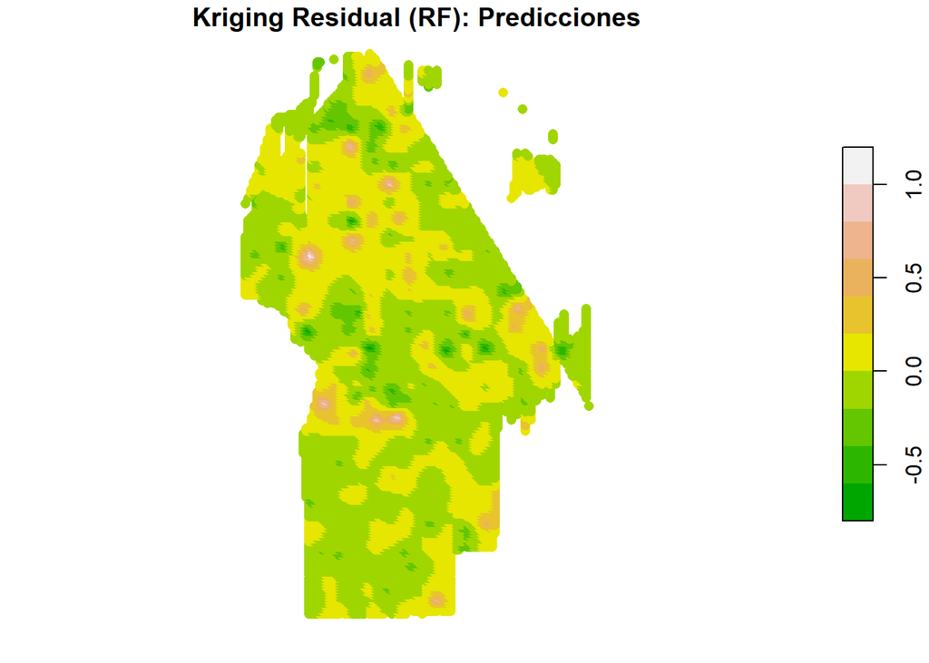

```r
plot(kgresRF["var1.pred"],
     main = "Kriging Residual (RF): Predicciones",
     pal = terrain.colors,
     pch = 16)
```

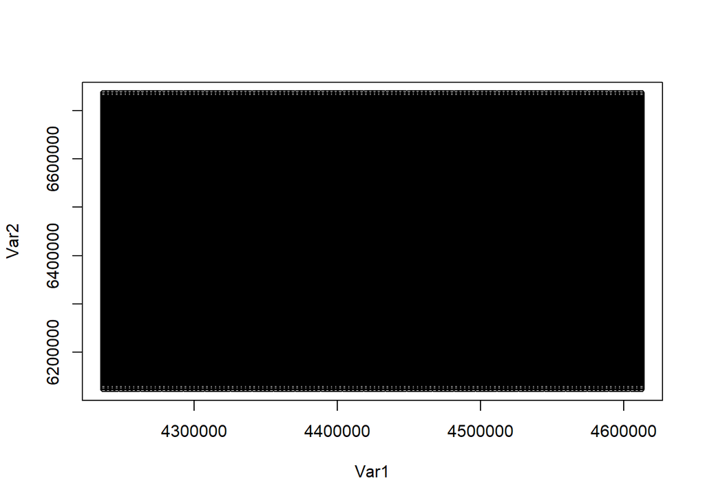

```r
# Generacion de grilla de prediccion para el Ranfom Forest:
gr <- pred_grid(grilla, by = 3000)
plot(gr)
```

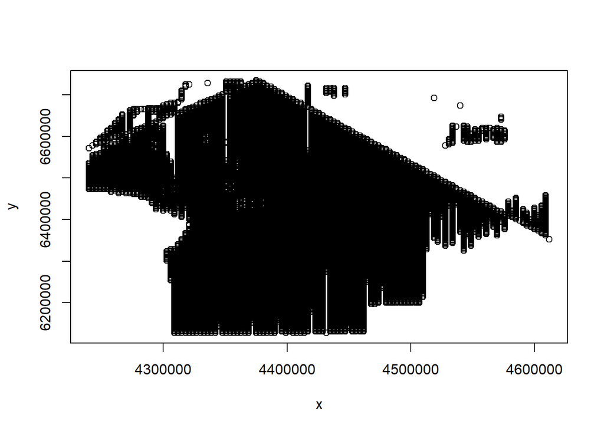

```r
gri <- polygrid(gr, bor = grilla)
rn<-rownames(gri)
names(gri)[1] <- paste("x")
names(gri)[2] <- paste("y")
plot(gri)
```

```r
grilla$RFK_pred <-predict(train_rf, newdata = grilla)

gridded(gri) = ~ x + y
gri <- st_as_sf(gri)
st_crs(gri) <- 22174
# mapview(gri)

# Cargo los valores de las covariables en la grilla de prediccion.
gri$NDVI<-0
gri$EPTmed<-0
gri$Pendiente<-0
gri$LC_Bosques<-0
gri$RFK_pred<-0
for(i in rn){
  gri[i,c("NDVI","EPTmed","Pendiente","LC_Bosques","RFK_pred")]<-grilla[i,c("NDVI","EPTmed","Pendiente","LC_Bosques","RFK_pred")]
}

# Eliminamos todas las filas que tengan prediccion 0, lo que quiere decir que los valores de las variables son cero:
gri<-gri[-which(gri$RFK_pred==0),]

# Aqui complemento el random forest con el kriging en las ubicaciones deseadas:
gri$RFK_pred+kgresRF$var1.pred
```

[output not shown]

[output cut: 1903 more lines]

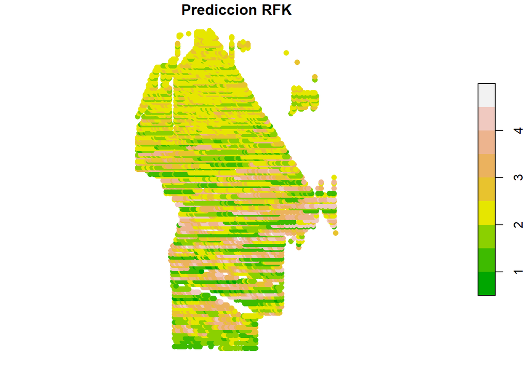

```r
plot(gri["RFK_pred"],
     main = "Prediccion RFK",
     pal = terrain.colors,
     pch = 16)
```

Ajustamos un semivariograma experimental a los residuos. Este semivariograma varia respecto al anteriormente ajustado sobre la variable respuesta en sentido que vemos que el efecto nugget decrece notablemente a un valor de 0.095 y el rango parece aumentar a un valor de 160000.

De esta forma procedemos a seleccionar un modelo teorico para el semivariograma. A pesar de no converger luego de 200 iteraciones, procedemos a seleccionar el mejor modelo que guardado, este es un Matteron con parametros sill de 0.1123919, rango de 8032.806 y kappa de 0.5.

## 5) Evalué y comprare la calidad de la predicción de los métodos utilizados (error de predicción).

```r
validacion <- function (fold, base, var.y) {
  require(caret)
  require(gstat)
  require(sp)

  datos <- read.table(base, head = T)
  names(datos)[names(datos) == var.y] <- "Y"

  if (base == "petrel.txt") {
    names(datos)[names(datos) == 'long'] <- "x"
    names(datos)[names(datos) == 'lat'] <- "y"
  }

  seed <- 7

  set.seed(seed)
  datos$id <-
    sample(rep(1:10, nrow(datos), length.out = nrow(datos)))

  list <- 1:10
  prediccion <- data.frame()
  testset <- data.frame()

  training <- subset(datos, id %in% list[-fold])
  testing <- subset(datos, id %in% c(fold))

  # Kriging Ordinario
  train_ko = training
  test_ko = testing
  coordinates(train_ko) <-  ~ x + y
  coordinates(test_ko) <-  ~ x + y
  vario <- variogram(Y ~ 1, train_ko)
  VF_vut_KO <- fit.variogram(vario, vgm(c("Sph", "Exp", "Gau")))
  KO <- krige(Y ~ 1, train_ko, test_ko, VF_vut_KO)

  # Regression Kriging
  train_ko = training
  test_ko = testing

  coordinates(train_ko) <-  ~ x + y
  coordinates(test_ko) <-  ~ x + y

  mlr <- lm(Y ~ x + y + NDVI + EPTmed + Pendiente , training)

  pred_mlr = predict(mlr, newdata = test_ko)

  inside_rk <- predict(mlr, newdata = train_ko)
  train_ko$error_rk <- training$Y - inside_rk

  vario_rk <- variogram(error_rk ~ 1, train_ko)
  model_rk_ko <-
    fit.variogram(vario_rk, vgm(nugget = 0.095, range = 160000, model=c("Exp", "Sph", "Gau", "Mat")))

  test_k <- krige(error_rk ~ 1 , train_ko, test_ko, model_rk_ko)
  test_rk_ko <- pred_mlr + test_k$var1.pred

  # Random Forest
  #fitControl <- trainControl(method = "cv", number = 10)
  fitControl <- trainControl(method = "none")
  #mtry <-data.frame(mtry=2)
  set.seed(seed)

  rf <- train(
    Y ~ x + y + NDVI + EPTmed + Pendiente,
    data = training,
    method = "rf",
    #tuneGrid =mtry,
    trControl = fitControl,
    verbose = FALSE
  )

  test_rf <- predict(rf, newdata = testing)

  # Random Forest + Kriging Ordinario
  inside_rf <- predict(rf, newdata = training)

  train_ko = training
  test_ko = testing

  coordinates(train_ko) <-  ~ x + y
  coordinates(test_ko) <-  ~ x + y

  train_ko$error_rf <- training$Y - inside_rf
  vario_rf <- variogram(error_rf ~ 1, train_ko)
  model_rf_ko <-
    fit.variogram(vario_rf, vgm(nugget = 0.095, range = 160000, model=c("Exp", "Sph", "Gau", "Mat")))
  test_ko <- krige(error_rf ~ 1 , train_ko, test_ko, model_rf_ko)
  test_rf_ko <- test_rf + test_ko$var1.pred


  # Tabla observados y predichos
  testset <- rbind(testset, as.data.frame(testing[, "Y"]))
  result <- data.frame(
    data.frame(
      "x" = testing$x,
      "y" = testing$y,
      "k-fold" = fold,
      "Observado" = testset[, 1],
      "KO" = KO$var1.pred,
      "RK" = test_rk_ko,
      "RF" = test_rf,
      "RF_KO" = test_rf_ko
    )
  )

  return(result)

}

num_cores <- detectCores() - 1
cl <- makeCluster(num_cores)
system.time(resultados <-
              do.call(
                rbind,
                parLapply(cl, 1:10, validacion, base = "MO_Córdoba.txt", var.y =
                            "MO")
              ))
```

```
##    user  system elapsed
##    0.01    0.00    8.19
```

```r
tabla <- resultados[, 4:8]
resumen <- function (j) {
  ME <- mean(tabla [, j] - tabla[, "Observado"])
  MAE <- mean(abs(tabla [, j] - tabla[, "Observado"]))
  MAPE <-
    mean(abs(tabla [, j] - tabla[, "Observado"]) / tabla[, "Observado"]) *
    100
  MSE <- mean((tabla [, j] - tabla[, "Observado"]) ^ 2)
  RMSE <- sqrt(mean((tabla [, j] - tabla[, "Observado"]) ^ 2))
  nRMSE <- sqrt(MSE) / mean(tabla[, "Observado"]) * 100
  rLM <- lm(tabla [, j] ~ tabla[, "Observado"])
  R2 <- as.matrix(summary(rLM)$adj.r.squared)
  mx <- mean(tabla[, "Observado"])
  my <- mean(tabla [, j])
  s2x <- var(tabla[, "Observado"])
  s2y <- var(tabla [, j])
  sxy <- mean((tabla[, "Observado"] - mx) * (tabla [, j] - my))
  resumen <-
    data.frame("Modelo" = names(tabla [j]), ME, MAE, MAPE, MSE, RMSE, nRMSE, R2)
  return(resumen)
}

tablafinal <- do.call("rbind", lapply(2:5, resumen))
tablafinal
```

```
##   Modelo           ME       MAE     MAPE       MSE      RMSE    nRMSE        R2
## 1     KO -0.005054250 0.5984806 29.56773 0.6230243 0.7893189 33.51924 0.3361951
## 2     RK -0.001715439 0.5862544 28.63395 0.6134054 0.7832020 33.25948 0.3572348
## 3     RF  0.006526448 0.5548974 27.49274 0.5581782 0.7471133 31.72693 0.4050497
## 4  RF_KO  0.002429543 0.5567897 27.48506 0.5619124 0.7496082 31.83288 0.4016765
```

A partir de los resultados obtenidos podemos ver que en estos datos el modelo de Random Forest sin Kriging ofrece muy buenos resultados, es el algoritmo que minimiza el RMSE. Ademas la combinacion de este algoritmo con el Kriging Oridinario no mejora los resultados previamente obtenidos. Por otra parte el Random Forest con Kriging Ordinario si mejora respecto al Kriging Ordinario y al Regresion Kriging.